# Data Analysis of Data Science Professionals

Authors: Connor Segneri (segneri3), Tom Fowler (tdf2)

STAT 420, Summer 2019, David Unger

July 29, 2019

## Introduction

The purpose of this project is to apply a thorough analysis of a dataset using many of the tools and techniques that have been taught throughout this course. More specifically, the end goal of this analysis is to develop a model that will be used for predicting the numeric response variable. The dataset that will be used is a multiple-choice survey developed by Kaggle as part of its second annual machine learning and data science survey challenge$_{[1]}$. This dataset contains a multitude of attributes that describe both macro groups (e.g., which survey participants prefer R over Python), as well as micro groups (e.g., technologies used by female students from Nigeria pursuing a PhD). To anyone with an interest in data science and machine learning, this dataset is truly a gold mine.

The dataset contains hundreds of attributes based on individual survey questions, and over 20,000 unique survey participants. The scope of our analysis will be narrowed down to participants who are *data scientists who reside in the United States*, and some of the attributes that are included in the dataset include:

- Age
- Salary
- Years of experience
- Type of data he/she works with (e.g., image, time series, text, etc.)
- Proportion of time spent working on industry DS practices, including:
  - Gathering data
  - Cleaning data
  - Visualizing data
  - Model building/model selection
  - Putting model into production
  - Finding and communicating data insights
- Proportion of time spent learning data science
  - Self-taught
  - Online courses
  - Work
  - University
  - Competitions
  - Other

The *numeric response variable*, given the attributes that have been laid out, can (most feasibly) be either age, salary, or years of experience. The one that will be chosen is **salary**, as salary insights can be very useful in this increasingly popular field. Additionally, the set of *predictors* that will be used includes the following:

- **Proportion of time spent learning data science**
  - Self-taught
  - Online courses
  - Work
  - University
  - Competitions
  - Other
- **Age**
- **Years of Experience**

This set of predictors was chosen because not only are they interesting, but they may reveal some consistent results. Plus, it would be great to be able to make a definitive and specific conclusion along the lines of (for example) “A data scientist who is 70% self-taught, is between 45-50 years old, and has 20-25 years of experience has the largest salary”. Using salary as the numeric response variable and these set of predictors, the analysis aims to answer the following question:

> **What is the salary of a data scientist in the United States given the proportion of time invested in learning data science, his/her age, and years of experience?**

This dataset was chosen because we are hitting two birds with one stone by analyzing this dataset. The first bird is applying what we have learned in this course to the project itself, and the second bird is having accurate insights of what data scientists are all about, proven by the model.

## Methods

This next section will describe and implement the analysis in detail. There may be some implementation details left out and referenced in the appendix section, as including them may clutter this section.

### Cleanup

Since it is not very feasible to show the first few rows of a several-hundred column dataset, dimensionality reduction can be used to extract the attributes that are necessary for the analysis. By definition, dimensionality reduction is a set of statistical techniques that are used to reduce the number of random variables/attributes to consider in a dataset$_{[2]}$. Traditionally, there are many ways to go about implementing dimensionality reduction. Popular methods include Principal Component Analysis (PCA), Backward Feature Elimination, High Correlation Filtering, and Low Variance Filtering. All of these methods are best suited for working with high dimensional, numerical, normalized data. A good example of data that meets this criteria would be images, since they are essentially matrices with floating point values to represent each pixel. However, with all of that said, it is safe to say that the data that has been loaded in does not require a need for these traditional methods. This is indicated by the fact that the multiple choice answers (i.e., the columns), can be weighted using these methods, but for the sake of answering the hypothesis, only the necessary attributes are worth keeping. Furthermore, everyone’s favorite dimensionality reduction technique can be used: brute-force attribute removal. The algorithm is simple: *subset the attributes from the rest of the dataset*. By effectively removing the unnecessary attributes, the dataset is one step closer to be used for effective model building. The implementation for this is included in the appendix$_{[A]}$. The result is a dataframe that contains the response and predictors, and here is a preview of it:

Response & predictors derived from dataset

| Salary | SelfTaught | Online | Work | University | Competitions | Other | Age | Experience |
| --- | --- | --- | --- | --- | --- | --- | --- | --- |
| 0-10,000 | 0 | 0 | 0 | 100 | 0 | 0 | 30-34 | 0-1 |
| 125-150,000 | 0 | 0 | 10 | 80 | 10 | 0 | 40-44 | 5-10 |
| 125-150,000 | 50 | 20 | 0 | 30 | 0 | 0 | 30-34 | 3-4 |
| 125-150,000 | 20 | 30 | 0 | 50 | 0 | 0 | 35-39 | 10-15 |
| 125-150,000 | 10 | 25 | 40 | 20 | 5 | 0 | 35-39 | 1-2 |
| 125-150,000 | 0 | 5 | 0 | 5 | 90 | 0 | 25-29 | 0-1 |

The next step involves factorizing any attributes that are labelled as ranges to become representative numeric values. These attributes include the response (*salary*), as well as the *age* and *years of experience* predictors. The fact that they were initially labelled in the dataset as ranges is in itself an indicator that each of these attributes are continuous. It makes sense too; for example, if individuals with higher salaries have more years of experience, the model should reflect this.

This cleanup step is necessary because right now, the ranges in the data are treated as character strings, and the `R` interpreter does not know that a salary range of “60-70,000” is greater than “50-60,000”. Due to the nature of this problem, the brute force approach would be to label each range with a numeric value. For simplicity and consistency, each value will be set to the minimum value of the range (e.g., `"50-60,000"` = `50,000`, `"1-2"` = `1`). Additionally, there was one observation that put a negative value for proportion of time spent on competitions, so this observation will be removed (to prevent providing inaccurate information). The code for this is included in the appendix$_{[B]}$. The result is a dataframe that contains the response and predictors with the response variable factorized to numeric values, and here is a preview of it:

Response & predictors derived from dataset, ranges factorized

| Salary | SelfTaught | Online | Work | University | Competitions | Other | Age | Experience |
| --- | --- | --- | --- | --- | --- | --- | --- | --- |
| 0 | 0 | 0 | 0 | 100 | 0 | 0 | 30 | 0 |
| 125000 | 0 | 0 | 10 | 80 | 10 | 0 | 40 | 5 |
| 125000 | 50 | 20 | 0 | 30 | 0 | 0 | 30 | 3 |
| 125000 | 20 | 30 | 0 | 50 | 0 | 0 | 35 | 10 |
| 125000 | 10 | 25 | 40 | 20 | 5 | 0 | 35 | 1 |
| 125000 | 0 | 5 | 0 | 5 | 90 | 0 | 25 | 0 |

Now that this dataset is completely cleaned up and ready to go, the analysis can officially begin.

### Multiple Linear Regression

To get an understanding of how each predictor is related to the salary, the first method that will be used in the analysis is multiple linear regression. To start things off straightforward, the **additive multiple linear regression model** will be constructed first:

$$Y = \beta_0 + \beta_1 x_1 + \beta_2 x_2 + \beta_3 x_3 + \beta_4 x_4 + \beta_5 x_5 + \beta_6 x_6 + \beta_7 x_7 + \beta_8 x_8 + \epsilon$$

where

- $Y$ is `Salary`
- $x_1$ is `SelfTaught`
- $x_2$ is `Online`
- $x_3$ is `Work`
- $x_4$ is `University`
- $x_5$ is `Competitions`
- $x_6$ is `Other`
- $x_7$ is `Age`
- $x_8$ is `Experience`

```r
add_mod = lm(Salary ~ ., data = data)
summary(add_mod)
```

```
##
## Call:
## lm(formula = Salary ~ ., data = data)
##
## Residuals:
##     Min      1Q  Median      3Q     Max
## -132823  -23450   -4587   21106  269751
##
## Coefficients: (1 not defined because of singularities)
##              Estimate Std. Error t value Pr(>|t|)
## (Intercept)   76081.1    16477.0    4.62  4.6e-06 ***
## SelfTaught      -87.0      158.8   -0.55    0.584
## Online         -323.1      167.2   -1.93    0.054 .
## Work             -2.6      158.7   -0.02    0.987
## University     -211.4      156.6   -1.35    0.177
## Competitions     30.6      188.8    0.16    0.871
## Other              NA         NA      NA       NA
## Age            1240.2      234.3    5.29  1.6e-07 ***
## Experience     2280.3      466.7    4.89  1.3e-06 ***
## ---
## Signif. codes:  0 '***' 0.001 '**' 0.01 '*' 0.05 '.' 0.1 ' ' 1
##
## Residual standard error: 44200 on 685 degrees of freedom
## Multiple R-squared:  0.179,  Adjusted R-squared:  0.17
## F-statistic: 21.3 on 7 and 685 DF,  p-value: <2e-16
```

Using this information as a guideline, the following can be extracted (the statistical tests will assume $\alpha = 0.05$):

- Null hypothesis: $H_0 = \beta_1 = \beta_2 = \beta_3 = \beta_4 = \beta_5 = \beta_6 = \beta_7 = \beta_8 = 0$.
- Alternative hypothesis: At least one of $\beta_j \ne 0$, $j = 1,2,3,4,5,6,7,8$.
- The value of the $F$-test statistic is $21.3176$.
- The $p$-value is $4.4806\times 10^{-26}$.
- Statistical decision: **Reject** $H_0$ at $\alpha = 0.05$.
- In conclusion, there is a linear relationship between `Salary` and at least one other predictor.
- The `Other` predictor is not defined because of singularities, and this is likely due to collinearity issues. It can be safely dropped from the model, and this is further supported by the fact that the term “Other” can have many implications and would be difficult to generalize if it was a significant predictor. Additionally, removing it from the additive model does not affect the estimates.

```r
library(dplyr)
data = select(data, -c("Other"))
```

Plugging in the derived coefficients, the model then becomes:

$$Y = \beta_0 + (-87.0) x_1 + (-323.1) x_2 + (-2.6) x_3 + (-211.4) x_4 + 30.6 x_5 + 1240.2 x_7 + 2280.3 x_8 + \epsilon$$

### Model Diagnostics

Next, let’s visualize this model and derive some more useful conclusions. A function from the homework will be used to generate these results, and is available in the appendix$_{[C]}$.

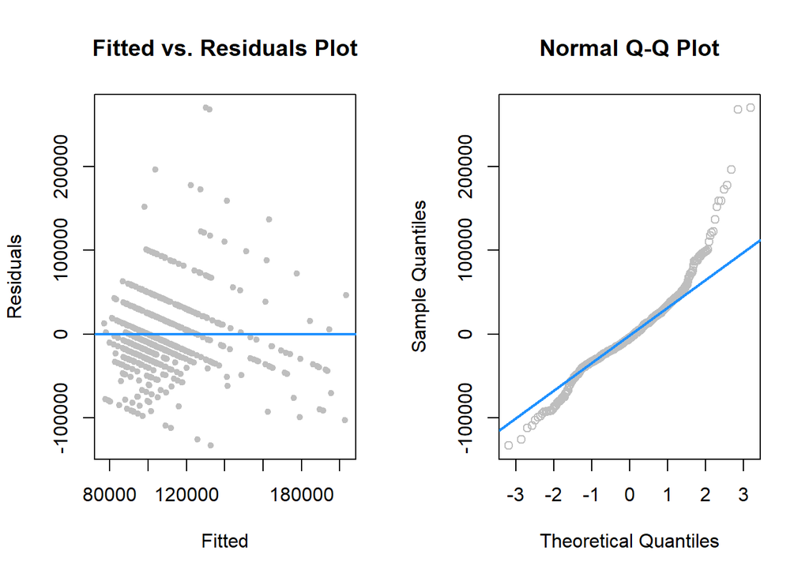

```r
diagnostics(add_mod,testit=F)
```

Based on these two plots of the model, two assumptions will be verified. These outcomes of these two assumptions will help further verify whether or not this is a good model.

- Based on the fitted vs. residuals plot, the **constant variance assumption** is violated. This is because the spread of residuals changes rather drastically at certain parts of the fitted model.
- Based on the normal Q-Q plot, the **normality assumption** is also violated. This is indicated by the “fat-tails” where the points diverge from the line for the lower and upper theoretical quantiles. We would probably not believe the errors follow a normal distribution.

### Model Exploration

Next, let’s create a few more models. We’ll compare them to one another and select the best model in the Results section.

The first step in determining which models to create is to take a look at the relationships between `Salary` and every other predictor. We’ll do this using the `pairs` function.

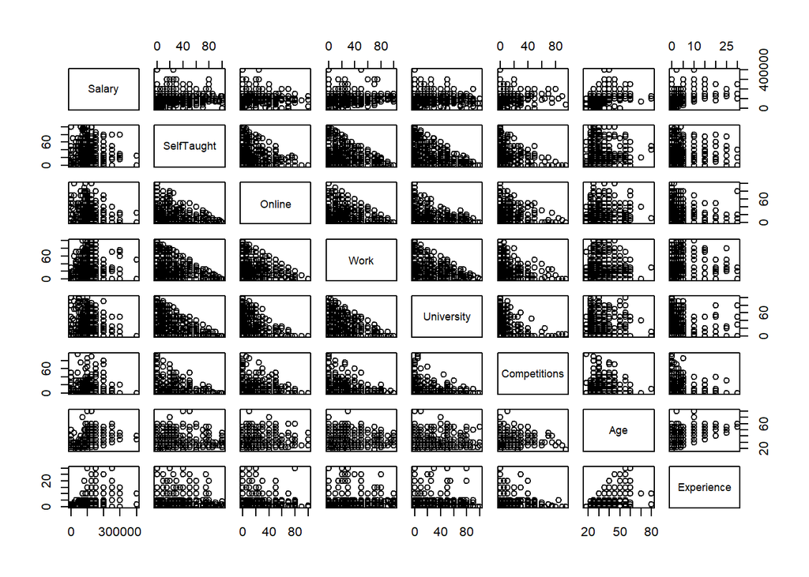

```r
pairs(data)
```

The first model is an additive model that only uses `Age` and `Experience` as predictors.

```r
simple_add_mod = lm(Salary ~ Age + Experience, data = data)
summary(simple_add_mod)$coefficients
```

```
##             Estimate Std. Error t value  Pr(>|t|)
## (Intercept)    65191     6816.6   9.563 1.966e-20
## Age             1196      232.6   5.142 3.550e-07
## Experience      2387      464.7   5.136 3.654e-07
```

The next model contains every predictor, and every interaction between every predictor.

```r
inter_mod = lm(Salary ~ .^2, data = data)
summary(inter_mod)$coefficients
```

```
##                            Estimate Std. Error  t value  Pr(>|t|)
## (Intercept)             -90231.6200  95050.275 -0.94930 3.428e-01
## SelfTaught                1339.6381    980.478  1.36631 1.723e-01
## Online                     965.5021   1009.082  0.95681 3.390e-01
## Work                      1183.4090   1000.004  1.18340 2.371e-01
## University                1049.0179    982.413  1.06780 2.860e-01
## Competitions              1232.0944   1070.729  1.15071 2.503e-01
## Age                       5953.4223   2948.145  2.01938 4.385e-02
## Experience               23864.4651   9316.238  2.56160 1.064e-02
## SelfTaught:Online            4.1189      5.089  0.80937 4.186e-01
## SelfTaught:Work              0.1412      3.659  0.03858 9.692e-01
## SelfTaught:University        5.8221      4.029  1.44519 1.489e-01
## SelfTaught:Competitions      0.1231      7.821  0.01574 9.875e-01
## SelfTaught:Age             -44.0860     30.383 -1.45101 1.472e-01
## SelfTaught:Experience      -91.7770     92.858 -0.98836 3.233e-01
## Online:Work                 11.0555      4.934  2.24057 2.538e-02
## Online:University            4.2514      6.040  0.70382 4.818e-01
## Online:Competitions         -4.9543      8.155 -0.60754 5.437e-01
## Online:Age                 -41.8054     30.924 -1.35186 1.769e-01
## Online:Experience         -111.9668     95.595 -1.17127 2.419e-01
## Work:University              4.6641      3.878  1.20270 2.295e-01
## Work:Competitions            3.4970      8.120  0.43066 6.669e-01
## Work:Age                   -38.0165     31.042 -1.22467 2.211e-01
## Work:Experience           -105.3866     93.220 -1.13052 2.587e-01
## University:Competitions      1.9560      9.195  0.21273 8.316e-01
## University:Age             -39.3758     30.404 -1.29510 1.957e-01
## University:Experience     -102.2978     93.160 -1.09808 2.726e-01
## Competitions:Age           -31.5523     33.505 -0.94172 3.467e-01
## Competitions:Experience   -120.7197    100.962 -1.19570 2.322e-01
## Age:Experience            -236.6747     37.462 -6.31776 4.863e-10
```

The last two models will use Backwards AIC (Akaike Information Criterion) to remove predictors from previous models in order to find a better fit. The first of these models will use the additive model that has every predictor. The second model will use the previously created model that has every interaction.

```r
add_mod_aic = step(add_mod, direction = "backward", trace = 0)
summary(add_mod_aic)$coefficients
```

```
##             Estimate Std. Error t value  Pr(>|t|)
## (Intercept)  72780.3    7191.61  10.120 1.550e-22
## Online        -286.3      93.34  -3.067 2.245e-03
## University    -179.8      68.98  -2.607 9.340e-03
## Age           1236.5     232.94   5.308 1.495e-07
## Experience    2262.4     462.73   4.889 1.262e-06
```

```r
inter_mod_aic = step(inter_mod, direction = "backward", trace = 0)
summary(inter_mod_aic)$coefficients
```

```
##                    Estimate Std. Error t value  Pr(>|t|)
## (Intercept)      -115867.93  91090.697  -1.272 2.038e-01
## SelfTaught          1586.43    928.418   1.709 8.796e-02
## Online              1324.82    959.056   1.381 1.676e-01
## Work                1523.35    943.655   1.614 1.069e-01
## University          1472.71    928.226   1.587 1.131e-01
## Competitions        1582.39   1014.960   1.559 1.194e-01
## Age                 7020.17   2731.923   2.570 1.039e-02
## Experience         13777.50   1783.437   7.725 4.026e-14
## SelfTaught:Age       -51.44     27.781  -1.852 6.450e-02
## Online:Work           10.26      4.743   2.163 3.092e-02
## Online:Age           -54.88     28.642  -1.916 5.579e-02
## Work:Age             -50.60     28.276  -1.789 7.399e-02
## University:Age       -50.50     27.877  -1.811 7.051e-02
## Competitions:Age     -47.72     30.663  -1.556 1.201e-01
## Age:Experience      -238.68     35.990  -6.632 6.778e-11
```

## Results

### Model Comparison

We’ll use the anova test to compare models, and find the best fit. The anova test computes an analysis of variance (or deviance) tables for one or more fitted model objects.

First I’ll compare all of the additive models. These are the full additive model, the model that only uses `Age` and `Experience` as predictors, and the additive model that was discovered using backward aic on the full additive model.

```r
anova(add_mod, simple_add_mod, add_mod_aic)
```

```
## Analysis of Variance Table
##
## Model 1: Salary ~ SelfTaught + Online + Work + University + Competitions +
##     Other + Age + Experience
## Model 2: Salary ~ Age + Experience
## Model 3: Salary ~ Online + University + Age + Experience
##   Res.Df      RSS Df Sum of Sq    F Pr(>F)
## 1    685 1.34e+12
## 2    690 1.36e+12 -5 -2.70e+10 2.77 0.0174 *
## 3    688 1.34e+12  2  2.43e+10 6.23 0.0021 **
## ---
## Signif. codes:  0 '***' 0.001 '**' 0.01 '*' 0.05 '.' 0.1 ' ' 1
```

Looking at the p-values, it seems like the additive model with the best fit is the one that was discovered using backward aic on the full additive model.

Next we’ll use the anova test to select the best interactive model. We fit two interactive models, one with every interaction, and one where we used backward aic.

```r
anova(inter_mod, inter_mod_aic)
```

```
## Analysis of Variance Table
##
## Model 1: Salary ~ (SelfTaught + Online + Work + University + Competitions +
##     Age + Experience)^2
## Model 2: Salary ~ SelfTaught + Online + Work + University + Competitions +
##     Age + Experience + SelfTaught:Age + Online:Work + Online:Age +
##     Work:Age + University:Age + Competitions:Age + Age:Experience
##   Res.Df      RSS  Df Sum of Sq    F Pr(>F)
## 1    664 1.22e+12
## 2    678 1.23e+12 -14 -1.25e+10 0.49   0.94
```

It looks like the interaction aic model is slightly better than the full interaction model.

For the final test, I’ll compare the interaction aic model with the additive aic to see which is the better fit.

```r
anova(add_mod_aic, inter_mod_aic)
```

```
## Analysis of Variance Table
##
## Model 1: Salary ~ Online + University + Age + Experience
## Model 2: Salary ~ SelfTaught + Online + Work + University + Competitions +
##     Age + Experience + SelfTaught:Age + Online:Work + Online:Age +
##     Work:Age + University:Age + Competitions:Age + Age:Experience
##   Res.Df      RSS Df Sum of Sq    F  Pr(>F)
## 1    688 1.34e+12
## 2    678 1.23e+12 10  1.06e+11 5.86 1.6e-08 ***
## ---
## Signif. codes:  0 '***' 0.001 '**' 0.01 '*' 0.05 '.' 0.1 ' ' 1
```

The interactive aic model is the best model we’ve fit, and is the model we select.

```r
summary(inter_mod_aic)
```

```
##
## Call:
## lm(formula = Salary ~ SelfTaught + Online + Work + University +
##     Competitions + Age + Experience + SelfTaught:Age + Online:Work +
##     Online:Age + Work:Age + University:Age + Competitions:Age +
##     Age:Experience, data = data)
##
## Residuals:
##     Min      1Q  Median      3Q     Max
## -164939  -22535   -3434   20404  235730
##
## Coefficients:
##                    Estimate Std. Error t value Pr(>|t|)
## (Intercept)      -115867.93   91090.70   -1.27    0.204
## SelfTaught          1586.43     928.42    1.71    0.088 .
## Online              1324.82     959.06    1.38    0.168
## Work                1523.35     943.66    1.61    0.107
## University          1472.71     928.23    1.59    0.113
## Competitions        1582.39    1014.96    1.56    0.119
## Age                 7020.17    2731.92    2.57    0.010 *
## Experience         13777.50    1783.44    7.73  4.0e-14 ***
## SelfTaught:Age       -51.44      27.78   -1.85    0.065 .
## Online:Work           10.26       4.74    2.16    0.031 *
## Online:Age           -54.88      28.64   -1.92    0.056 .
## Work:Age             -50.60      28.28   -1.79    0.074 .
## University:Age       -50.50      27.88   -1.81    0.071 .
## Competitions:Age     -47.72      30.66   -1.56    0.120
## Age:Experience      -238.68      35.99   -6.63  6.8e-11 ***
## ---
## Signif. codes:  0 '***' 0.001 '**' 0.01 '*' 0.05 '.' 0.1 ' ' 1
##
## Residual standard error: 42600 on 678 degrees of freedom
## Multiple R-squared:  0.243,  Adjusted R-squared:  0.227
## F-statistic: 15.5 on 14 and 678 DF,  p-value: <2e-16
```

### Assumptions

Now we’ll check if the model selected follows the constant variance and normality assumptions. For the constant variance assumptions we’ll use the Breusch-Pagan test, and for the normality assumption we’ll use the Shapiro-Wilk test.

```r
library(lmtest)
bptest(inter_mod_aic)
```

```
##
##  studentized Breusch-Pagan test
##
## data:  inter_mod_aic
## BP = 102, df = 14, p-value = 2e-15
```

The null hypothesis for this test is that the errors have constant variance about the true model. Looking at the p-value, we reject the null hypothesis. The errors have a non-constant variance about the true model.

```r
shapiro.test(resid(inter_mod_aic))
```

```
##
##  Shapiro-Wilk normality test
##
## data:  resid(inter_mod_aic)
## W = 0.94, p-value <2e-16
```

The null hypothesis for this test assumes the data were sampled from a normal distribution. The small p-value above indicates that there is only a small probability the data could have been sampled from a normal distribution.

## Discussion

### Assumptions

As shown in the Results section, the normality assumption and the constant variance assumptions were not met for the best model we could come up with. Since the assumptions have not been met, this means that we can still “perform” a t-test using `R`, but the results are not valid. The distributions of the parameter estimates will not be what we expect. Hypothesis tests will then accept or reject incorrectly.

### Testing the Model

```r
summary(inter_mod_aic)$coefficients
```

```
##                    Estimate Std. Error t value  Pr(>|t|)
## (Intercept)      -115867.93  91090.697  -1.272 2.038e-01
## SelfTaught          1586.43    928.418   1.709 8.796e-02
## Online              1324.82    959.056   1.381 1.676e-01
## Work                1523.35    943.655   1.614 1.069e-01
## University          1472.71    928.226   1.587 1.131e-01
## Competitions        1582.39   1014.960   1.559 1.194e-01
## Age                 7020.17   2731.923   2.570 1.039e-02
## Experience         13777.50   1783.437   7.725 4.026e-14
## SelfTaught:Age       -51.44     27.781  -1.852 6.450e-02
## Online:Work           10.26      4.743   2.163 3.092e-02
## Online:Age           -54.88     28.642  -1.916 5.579e-02
## Work:Age             -50.60     28.276  -1.789 7.399e-02
## University:Age       -50.50     27.877  -1.811 7.051e-02
## Competitions:Age     -47.72     30.663  -1.556 1.201e-01
## Age:Experience      -238.68     35.990  -6.632 6.778e-11
```

That being said, looking at the model, it seems as though the predictors we would expect have the highest correlation in determining what a data scientist’s salary would be.

```r
summary(inter_mod_aic)
```

```
##
## Call:
## lm(formula = Salary ~ SelfTaught + Online + Work + University +
##     Competitions + Age + Experience + SelfTaught:Age + Online:Work +
##     Online:Age + Work:Age + University:Age + Competitions:Age +
##     Age:Experience, data = data)
##
## Residuals:
##     Min      1Q  Median      3Q     Max
## -164939  -22535   -3434   20404  235730
##
## Coefficients:
##                    Estimate Std. Error t value Pr(>|t|)
## (Intercept)      -115867.93   91090.70   -1.27    0.204
## SelfTaught          1586.43     928.42    1.71    0.088 .
## Online              1324.82     959.06    1.38    0.168
## Work                1523.35     943.66    1.61    0.107
## University          1472.71     928.23    1.59    0.113
## Competitions        1582.39    1014.96    1.56    0.119
## Age                 7020.17    2731.92    2.57    0.010 *
## Experience         13777.50    1783.44    7.73  4.0e-14 ***
## SelfTaught:Age       -51.44      27.78   -1.85    0.065 .
## Online:Work           10.26       4.74    2.16    0.031 *
## Online:Age           -54.88      28.64   -1.92    0.056 .
## Work:Age             -50.60      28.28   -1.79    0.074 .
## University:Age       -50.50      27.88   -1.81    0.071 .
## Competitions:Age     -47.72      30.66   -1.56    0.120
## Age:Experience      -238.68      35.99   -6.63  6.8e-11 ***
## ---
## Signif. codes:  0 '***' 0.001 '**' 0.01 '*' 0.05 '.' 0.1 ' ' 1
##
## Residual standard error: 42600 on 678 degrees of freedom
## Multiple R-squared:  0.243,  Adjusted R-squared:  0.227
## F-statistic: 15.5 on 14 and 678 DF,  p-value: <2e-16
```

Looking at the p-values for the individual t-tests performed for each predictor used above, we see that `Experience` and `Age` are the two predictors that the model suggests have the most influence on a data scientist’s salary, with the relationship between `Age` and `Experience` having more influence than `Age` by itself.

### R-Squared

The R-Squared value for a model is a statistical measure of how close the data are to the fitted regression line. It is the percentage of the response variable variation that is explained by a linear model. The R-Squared for our chosen model is `0.2427`. This indicates that the model explains about `24%` of the variability of the response data around its mean. While this is the best R-Squared value of the models we created, (except for the full interactive model which was `0.2504`) it is not a very good R-Squared value. We would say that this model doesn’t do a very good job at explaining the response variable variation.

### Conclusion

Although the interactive model discovered by utilizing backward aic is more useful in predicting a data scientist’s salary than the other models we created, we can’t confidently say it is useful on it’s own. Breaking the assumptions of linear regression combined with its low R-Squared value indicate that we haven’t found predictors that can meaningfully predict a data scientist’s salary (at least with the data we’ve been using in this report). It was interesting to see how significant the relationship between `Experience` and `Age` were in predicting a data scientist’s salary in the model that we selected, but we can’t draw any real conclusions as of now.

## Appendix

This section is used to contain blocks of code that are not necessary to include directly in the report, but were used in the analysis.

### Appendix A

```r
# Load data
data = read.csv('multipleChoiceResponses.csv',header=T,na.strings=c(""," ","NA"))

# Some cleaning
data = data[,c(8,5,13,285:290,4,12)]
data = data[data[,1] == "Data Scientist",]
data = data[data[,2] == "United States of America",]
data = data[!grepl("I do not",data[,3]),]
data = data[complete.cases(data),]
colnames(data) = c("Position","Location","Salary","SelfTaught","Online","Work",
                   "University","Competitions","Other","Age","Experience")
rownames(data) = c()

# Remove the position and location attributes,
# which were necessary for subsetting the data
data = data[,-1]
data = data[,-1]

# Preview
knitr::kable(head(data),caption="Response & predictors derived from dataset")
dim(data)
```

### Appendix B

```r
# Setup
library(plyr)
sal_data = as.character(data[,1])
age_data = as.character(data[,8])
exp_data = as.character(data[,9])

# Factorize the salary values
sal_data = revalue(sal_data,c("0-10,000" = 0,
                               "10-20,000" = 10000,
                               "20-30,000" = 20000,
                               "30-40,000" = 30000,
                               "40-50,000" = 40000,
                               "50-60,000" = 50000,
                               "60-70,000" = 60000,
                               "70-80,000" = 70000,
                               "80-90,000" = 80000,
                               "90-100,000" = 90000,
                               "100-125,000" = 100000,
                               "125-150,000" = 125000,
                               "150-200,000" = 150000,
                               "200-250,000" = 200000,
                               "250-300,000" = 250000,
                               "300-400,000" = 300000,
                               "400-500,000" = 400000))

# Factorize the age values
age_data = revalue(age_data,c("18-21" = 18,
                               "22-24" = 22,
                               "25-29" = 25,
                               "30-34" = 30,
                               "35-39" = 35,
                               "40-44" = 40,
                               "45-49" = 45,
                               "50-54" = 50,
                               "55-59" = 55,
                               "60-69" = 60,
                               "70-79" = 70,
                               "80+" = 80))

# Factorize the years of experience values
exp_data = revalue(exp_data,c("0-1" = 0,
                               "1-2" = 1,
                               "2-3" = 2,
                               "3-4" = 3,
                               "4-5" = 4,
                               "5-10" = 5,
                               "10-15" = 10,
                               "15-20" = 15,
                               "20-25" = 20,
                               "25-30" = 25,
                               "30 +" = 30))

# Replace data with factorized values
data[,1] = as.numeric(sal_data)
data[,8] = as.numeric(age_data)
data[,9] = as.numeric(exp_data)

# Convert rest of dataset to numeric
data[,2] = as.numeric(as.character(data[,2]))
data[,3] = as.numeric(as.character(data[,3]))
data[,4] = as.numeric(as.character(data[,4]))
data[,5] = as.numeric(as.character(data[,5]))
data[,6] = as.numeric(as.character(data[,6]))
data[,7] = as.numeric(as.character(data[,7]))
data[,8] = as.numeric(as.character(data[,8]))
data[,9] = as.numeric(as.character(data[,9]))

# Remove the one person who thought it would be funny to
# put a negative value in the proportion of competition time
data = data[-57,]

# Preview
knitr::kable(head(data),caption="Response & predictors derived from dataset, ranges factorized")
```

### Appendix C

```r
diagnostics = function(model, pcol = 'grey', lcol = 'dodgerblue', alpha = 0.05, plotit = T, testit = T)
{
  if(plotit == T)
  {
    par(mfrow=c(1,2))

    # Fitted vs. Residuals
    plot(fitted(model), resid(model), col = pcol, pch = 20,
      xlab = "Fitted", ylab = "Residuals", main = "Fitted vs. Residuals Plot")
    abline(h = 0, col = lcol, lwd = 2)

    # Q-Q Plot
    qqnorm(resid(model), main = "Normal Q-Q Plot", col = pcol)
    qqline(resid(model), col = lcol, lwd = 2)
  }
  if(testit == T)
  {
    p_val = shapiro.test(resid(model))$p.value
    decision = ifelse(p_val <= alpha,"Reject","Fail to Reject")
    return(list('p_val' = p_val, 'decision' = decision))
  }
}
```

## References

[1)](https://www.kaggle.com/kaggle/kaggle-survey-2018/home) *Kaggle*. (2018, November 03). 2018 Kaggle ML & DS Survey Challenge. Retrieved July 16, 2019.  
[2)](https://www.techopedia.com/definition/30392/dimensionality-reduction) *What is Dimensionality Reduction? - Definition from Techopedia*. (n.d.). Retrieved July 16, 2019.